# Lecture 13: Data Preparation I

```python
# to save space, do a symbolic link to previous lecture's data
!ln -sf ../lec11/data .
```

```python
import pandas as pd
```

```python
mm = pd.read_csv('data/mm.txt', header=0)
mm
```

|  | Year | OCT | NOV | DEC | JAN | FEB | MAR | APR | MAY | JUN | JUL | AUG | SEP |
| --- | --- | --- | --- | --- | --- | --- | --- | --- | --- | --- | --- | --- | --- |
| 0 | 2002 | 545.92 | 3115.08 | 3996.76 | 1815.74 | 1204.14 | 1644.02 | 795.92 | 540.24 | 112.62 | 79.52 | 22.20 | 171.70 |
| 1 | 2003 | 55.41 | 1242.23 | 2976.94 | 797.72 | 836.01 | 1026.11 | 1571.27 | 468.59 | 24.93 | 98.33 | 267.40 | 99.20 |
| 2 | 2004 | 55.90 | 834.40 | 2311.72 | 942.75 | 2019.22 | 399.52 | 339.18 | 251.64 | 72.38 | 55.57 | 116.74 | 97.48 |
| 3 | 2006 | 347.22 | 908.44 | 2981.16 | 1793.97 | 995.27 | 2031.19 | 1602.55 | 287.21 | 102.44 | 90.31 | 18.75 | 33.76 |
| 4 | 2005 | 1449.23 | 619.77 | 1789.93 | 1777.23 | 1055.41 | 1472.91 | 743.11 | 1113.26 | 309.19 | 46.61 | 86.51 | 93.98 |
| 5 | 2007 | 178.81 | 942.89 | 1279.33 | 320.66 | 1615.47 | 317.77 | 519.85 | 150.15 | 85.32 | 102.60 | 62.74 | 164.02 |
| 6 | 2008 | 612.92 | 329.64 | 1189.43 | 2153.17 | 1007.57 | 316.55 | 153.53 | 255.80 | 42.45 | 41.73 | 36.83 | 12.59 |
| 7 | 2009 | 272.27 | 777.81 | 1102.87 | 533.64 | 1479.80 | 881.30 | 297.80 | 580.28 | 320.84 | 35.95 | 53.25 | 42.99 |
| 8 | 2010 | 722.61 | 379.36 | 1029.03 | 1780.54 | 1136.93 | 814.83 | 1225.52 | 487.75 | 146.90 | 38.05 | 46.77 | 88.72 |
| 9 | 2011 | 1059.68 | 1016.81 | 2555.51 | 463.27 | 1059.94 | 2173.84 | 465.80 | 552.36 | 350.04 | 84.51 | 21.59 | 76.77 |
| 10 | 2020 | 56.21 | 311.24 | 1202.38 | 578.53 | 70.34 | 789.14 | 509.50 | 375.76 | 70.86 | 17.71 | 25.99 | 21.65 |
| 11 | 2012 | 527.67 | 523.53 | 156.69 | 1066.21 | 421.75 | 1643.46 | 828.51 | 115.19 | 164.73 | 98.85 | 92.70 | 45.65 |
| 12 | 2014 | 119.18 | 281.26 | 178.54 | 233.12 | 1314.08 | 978.52 | 376.71 | 179.59 | 42.21 | 96.86 | 163.17 | 244.05 |
| 13 | 2013 | 376.65 | 1131.15 | 1759.84 | 338.40 | 189.12 | 391.51 | 259.37 | 254.56 | 142.22 | 72.63 | 96.91 | 343.69 |
| 14 | 2015 | 342.81 | 551.60 | 1654.38 | 149.87 | 860.72 | 243.26 | 343.53 | 338.50 | 109.07 | 201.23 | 49.52 | 84.94 |
| 15 | 2016 | 305.11 | 635.79 | 1530.09 | 1754.74 | 367.08 | 1395.37 | 427.64 | 245.77 | 110.11 | 37.56 | 28.19 | 52.88 |
| 16 | 2017 | 1175.34 | 581.67 | 1155.19 | 2628.17 | 2110.15 | 751.90 | 825.07 | 153.14 | 118.32 | 53.72 | 72.88 | 156.63 |
| 17 | 2018 | 130.64 | 967.23 | 118.69 | 847.21 | 201.54 | 1540.98 | 578.42 | 201.33 | 43.35 | 68.03 | 22.84 | 14.06 |
| 18 | 2019 | 199.39 | 754.07 | 585.14 | 1282.06 | 2261.94 | 1090.67 | 442.48 | 743.01 | 48.86 | 25.14 | 48.34 | 208.95 |

# Data Unboxing, Part I

```python
!du -h data/*
```

```
1.4M	data/jc1.txt
51M	data/jq2.txt
600K	data/mmp.txt
4.3M	data/mmr.txt
4.0K	data/mm.txt
628K	data/mpf.txt
4.0K	data/requirements.txt
```

```python
!ls -lh data/*
```

```
-rw-r--r-- 1 jovyan jovyan 1.4M Feb 28 20:14 data/jc1.txt
-rw-r--r-- 1 jovyan jovyan  51M Feb 28 20:14 data/jq2.txt
-rw-r--r-- 1 jovyan jovyan 600K Feb 28 20:14 data/mmp.txt
-rw-r--r-- 1 jovyan jovyan 4.3M Feb 28 20:14 data/mmr.txt
-rw-r--r-- 1 jovyan jovyan 4.0K Feb 28 20:14 data/mm.txt
-rw-r--r-- 1 jovyan jovyan 627K Feb 28 20:14 data/mpf.txt
-rw-r--r-- 1 jovyan jovyan 2.1K Feb 28 20:14 data/requirements.txt
```

What category of data is the file below? Any observations about the data?

```python
!head -c 1024 data/jc1.txt
```

```
_input,_num,_widgetName,_source,_resultNumber,_pageUrl,game_number,bio1,bio2,bio3,contestant1_name,contestant1_score,contestant2_name,contestant2_score,contestant3_name,contestant3_score
,1,Jeopardy_Winners,Jeopardy_Winners,1,http://www.j-archive.com/showgame.php?game_id=3350,Show #5883 - Wednesday March 24 2010,Derek Honoré an attorney from Inglewood California,Tatiana Walton a graphic designer from Cutler Bay Florida,Regina Robbins an arts teacher from New York New York (whose 1-d…
,2,Jeopardy_Winners,Jeopardy_Winners,2,http://www.j-archive.com/showgame.php?game_id=4400,Show #6756 - Monday January 20 2014,Jon McGuire a software-development manager from Matthews North Carolina,Blake Perkins an environmental scientist from Baton Rouge Louisiana,Sarah McNitt a study abroad advise…
,3,Jeopardy_Winners,Jeopardy_Winners,3,http://www.j
```

**Exercise**: What do you see this time? Category? Interesting features of the data?

```python
!head -c 1024 data/jq2.txt
```

```
{"category":"HISTORY","air_date":"2004-12-31","question":"'For the last 8 years of his life, Galileo was under house arrest for espousing this man's theory'","value":"$200","answer":"Copernicus","round":"Jeopardy!","show_number":"4680"}
{"category":"ESPN's TOP 10 ALL-TIME ATHLETES","air_date":"2004-12-31","question":"'No. 2: 1912 Olympian; football star at Carlisle Indian School; 6 MLB seasons with the Reds, Giants & Braves'","value":"$200","answer":"Jim Thorpe","round":"Jeopardy!","show_number":"4680"}
{"category":"EVERYBODY TALKS ABOUT IT...","air_date":"2004-12-31","question":"'The city of Yuma in this state has a record average of 4,055 hours of sunshine each year'","value":"$200","answer":"Arizona","round":"Jeopardy!","show_number":"4680"}
{"category":"THE COMPANY LINE","air_date":"2004-12-31","question":"'In 1963, live on \"The Art Linkletter Show\", this company served its billionth burger'","value":"$200","answer":"McDonald\\'s","round":"Jeopardy!","show_number":"4680"}
{"category":"EPITAPHS & TRIBUTE
```

## [On your own] Data Unboxing, Part II

Let's explore the first file here:

```python
!head -c 1024 data/jc1.txt
```

```
_input,_num,_widgetName,_source,_resultNumber,_pageUrl,game_number,bio1,bio2,bio3,contestant1_name,contestant1_score,contestant2_name,contestant2_score,contestant3_name,contestant3_score
,1,Jeopardy_Winners,Jeopardy_Winners,1,http://www.j-archive.com/showgame.php?game_id=3350,Show #5883 - Wednesday March 24 2010,Derek Honoré an attorney from Inglewood California,Tatiana Walton a graphic designer from Cutler Bay Florida,Regina Robbins an arts teacher from New York New York (whose 1-d…
,2,Jeopardy_Winners,Jeopardy_Winners,2,http://www.j-archive.com/showgame.php?game_id=4400,Show #6756 - Monday January 20 2014,Jon McGuire a software-development manager from Matthews North Carolina,Blake Perkins an environmental scientist from Baton Rouge Louisiana,Sarah McNitt a study abroad advise…
,3,Jeopardy_Winners,Jeopardy_Winners,3,http://www.j
```

```python
import numpy as np
import warnings
warnings.simplefilter(action='ignore', category=FutureWarning)
import pandas as pd

jc1 = pd.read_csv('data/jc1.txt', header=0, sep=',')
jc1.head(3)
```

|  | _input | _num | _widgetName | _source | _resultNumber | _pageUrl | game_number | bio1 | bio2 | bio3 | contestant1_name | contestant1_score | contestant2_name | contestant2_score | contestant3_name | contestant3_score |
| --- | --- | --- | --- | --- | --- | --- | --- | --- | --- | --- | --- | --- | --- | --- | --- | --- |
| 0 | NaN | 1 | Jeopardy_Winners | Jeopardy_Winners | 1 | http://www.j-archive.com/showgame.php?game_id=... | Show #5883 - Wednesday March 24 2010 | Derek Honoré an attorney from Inglewood Califo... | Tatiana Walton a graphic designer from Cutler ... | Regina Robbins an arts teacher from New York N... | Regina | $19401 | Tatiana | $7100 | Derek | $11900 |
| 1 | NaN | 2 | Jeopardy_Winners | Jeopardy_Winners | 2 | http://www.j-archive.com/showgame.php?game_id=... | Show #6756 - Monday January 20 2014 | Jon McGuire a software-development manager fro... | Blake Perkins an environmental scientist from ... | Sarah McNitt a study abroad adviser originally... | Sarah | $20199 | Blake | $0 | Jon | $8380 |
| 2 | NaN | 3 | Jeopardy_Winners | Jeopardy_Winners | 3 | http://www.j-archive.com/showgame.php?game_id=... | Show #5754 - Thursday September 24 2009 | Christopher Nold an economics and film studies... | Rachel Landau a museum night security guard fr... | Joann Mariani a high school English teacher fr... | Joann | $99 | Rachel | NaN | Christopher | $23000 |

What data types are each column?

```python
jc1.dtypes
```

```
_input               float64
_num                   int64
_widgetName           object
_source               object
_resultNumber          int64
_pageUrl              object
game_number           object
bio1                  object
bio2                  object
bio3                  object
contestant1_name      object
contestant1_score     object
contestant2_name      object
contestant2_score     object
contestant3_name      object
contestant3_score     object
dtype: object
```

Currently, we're working with objects, because of how pandas read in the dtypes. Let's try to modify some scores here for contestants to make them numbers

```python
jc1.columns
for col in jc1.columns:
    if '_score' in col:
        jc1[col] = jc1[col].map(lambda x: float(x.strip('$')) if type(x) == str else np.nan)
```

What are our dtypes now?

```python
jc1.dtypes
```

```
_input               float64
_num                   int64
_widgetName           object
_source               object
_resultNumber          int64
_pageUrl              object
game_number           object
bio1                  object
bio2                  object
bio3                  object
contestant1_name      object
contestant1_score    float64
contestant2_name      object
contestant2_score    float64
contestant3_name      object
contestant3_score    float64
dtype: object
```

Can we visualize our contestant winnings?

```
array([[<Axes: title={'center': 'contestant3_score'}>]], dtype=object)
```

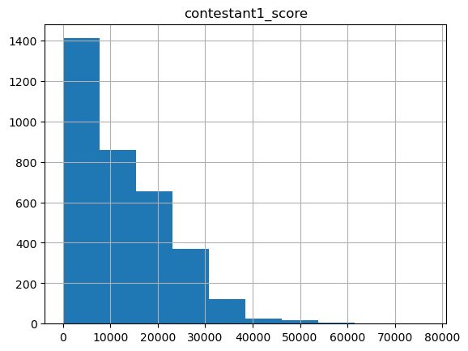

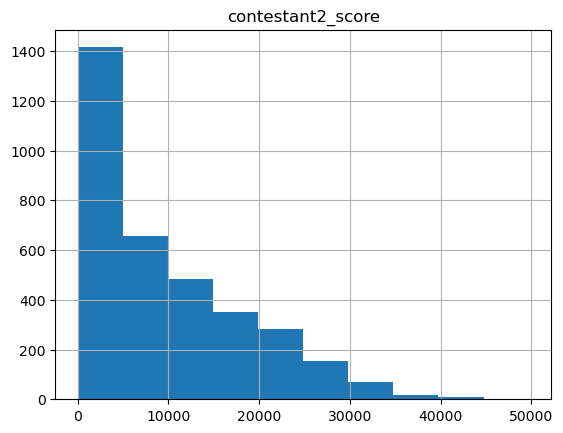

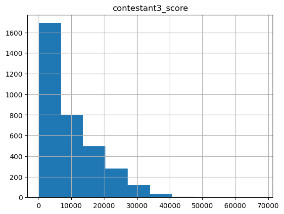

```python
jc1.hist(column='contestant1_score')
jc1.hist(column='contestant2_score')
jc1.hist(column='contestant3_score')
```

# CNRFC-NOAA Rainfall Dataset

- There are four data files tied to the scrape of rainfall data from the NOAA (National Oceanic and Atmospheric Administration) [link](https://www.cnrfc.noaa.gov/monthly_precip_2020.php).
- This was compiled by visiting each annual website of monthly precipitation by regions in the California Nevada River Forecast Center (CNRFC) area.
- For more details on how to make this dataset yourself, check out the `rainfallscrape` folder. You may need to install additional Python packages via `pip -r rainfallscrape/requirements.txt`.

Let's unbox this data too:

```python
!ls -lh data/m*
```

```
-rw-r--r-- 1 jovyan jovyan 600K Feb 28 20:14 data/mmp.txt
-rw-r--r-- 1 jovyan jovyan 4.3M Feb 28 20:14 data/mmr.txt
-rw-r--r-- 1 jovyan jovyan 4.0K Feb 28 20:14 data/mm.txt
-rw-r--r-- 1 jovyan jovyan 627K Feb 28 20:14 data/mpf.txt
```

All of these files *look* rectangular. **What data model does each follow, structurally?**

Analyze the first few lines of each file in order below. Remember to adjust `-n` number of lines as needed.

1. `mm.txt`
2. `mmp.txt`
3. `mmr.txt`
4. `mpf.txt` - may need to look at first 20 lines here

```python
!head -n 20 data/mpf.txt
```

```
Year,ID,Location,Station,OCT,NOV,DEC,JAN,FEB,MAR,APR,MAY,JUN,JUL,AUG,SEP
2002,4BK,BROOKINGS,SOUTHERN OREGON COASTAL,6.43,14.53,17.32,17.32,9.1,6.05,6.62,3.65,3.68,0.02,0.03,1.45
2002,ASHO3,ASHLAND,SOUTHERN OREGON COASTAL,0.38,3.5,3.41,1.32,1.29,1.29,2.92,1.88,0.08,0.28,0,0.2
2002,COPO3,COPPER 4NE,SOUTHERN OREGON COASTAL,0.29,6.68,6.98,3.42,1.99,1.8,,,,,,0.27
2002,CVJO3,CAVE JUNCTION,SOUTHERN OREGON COASTAL,2.46,13.6,14.81,9.76,6.46,4.63,1.94,0.89,0,0,0,0.33
2002,GOLO3,GOLD BEACH,SOUTHERN OREGON COASTAL,4.63,11.72,16.59,14.58,8.89,6.62,4.73,1.5,2.09,0.02,0,0.62
2002,GPSO3,GRANTS PASS KAJO,SOUTHERN OREGON COASTAL,0.39,6.37,6.94,4.31,2.89,1.36,0.87,0.62,0.02,0,0,0.05
2002,GSPO3,GREEN SPRINGS PP,SOUTHERN OREGON COASTAL,0.36,4.79,5.9,2.52,1.47,1.74,2.41,1.15,0.11,0.01,0,0.2
2002,LEMO3,LEMOLO LAKE,SOUTHERN OREGON COASTAL,5.13,10.3,12.72,11.48,4.99,6.32,5.49,1.14,2.22,0.4,0.2,2.13
2002,MFR,MEDFORD,SOUTHERN OREGON COASTAL,0.19,4.16,4.34,1.59,1.65,1.33,1.49,0.53,0.03,0.08,0,0.54
2002,OTH,NORTH BEND,SOUTHERN OREGON COASTAL,4.45,10.25,14.1,15.79,4.14,6.67,4.56,1.48,1.42,0.01,0.22,1.33
2002,PRSO3,PROSPECT 2SW,SOUTHERN OREGON COASTAL,1.78,7.17,9.1,5.86,3.45,3.51,2.88,0.65,0.34,0.03,0,0.82
2002,RIDO3,RIDDLE,SOUTHERN OREGON COASTAL,1.02,6.84,6.71,4.81,2.76,1.71,1.23,1.3,0.26,0.02,0,0.24
2002,ROGO3,ROSEBURG,SOUTHERN OREGON COASTAL,1.91,6.88,6.65,4.83,2.4,0.85,1.54,1.13,0.19,0,0,0.32
2002,SXT,SEXTON SUMMIT,SOUTHERN OREGON COASTAL,0.28,5.13,5.75,5.75,3.03,2.9,1.63,1.08,0.07,0.01,0,0.2
2002,TKFO3,TOKETEE FALLS,SOUTHERN OREGON COASTAL,3.23,7.45,9.59,6.94,3.54,4.06,3.31,1.22,1.17,0.04,0.02,1.99
2002,WINO3,WINCHESTER DAM,SOUTHERN OREGON COASTAL,1.66,7.37,7.39,5.32,2.77,2.93,1.46,1.29,0.25,0,0.08,0.65
2002,WLMO3,WILLIAMS,SOUTHERN OREGON COASTAL,0.4,7.11,7.98,7.98,2.68,2.68,1.79,0.46,0,0,0,0.08
2002,DNON2,DENIO,OREGON CLOSED BASINS,0.25,1.54,1.37,0.69,0.91,0.56,0.83,0.15,0.12,0,0.08,0.53
2002,HMRO3,HART MOUNTAIN REF,OREGON CLOSED BASINS,0.34,1.37,0.61,0.67,0.63,0.72,1.45,0.6,0.66,0,0.15,0.57
```

## Fulfilling Structural Transformation Requests

Let's start from the long (tidy, relational) file:

```python
pd.set_option('display.min_rows', 15) # changes truncated view in pandas
```

```python
mmr = pd.read_csv('data/mmr.txt')
mmr
```

|  | Year | ID | Location | Station | Month | Inches of Precipitation |
| --- | --- | --- | --- | --- | --- | --- |
| 0 | 2002 | 4BK | BROOKINGS | SOUTHERN OREGON COASTAL | OCT | 6.43 |
| 1 | 2002 | 4BK | BROOKINGS | SOUTHERN OREGON COASTAL | NOV | 14.53 |
| 2 | 2002 | 4BK | BROOKINGS | SOUTHERN OREGON COASTAL | DEC | 17.32 |
| 3 | 2002 | 4BK | BROOKINGS | SOUTHERN OREGON COASTAL | JAN | 17.32 |
| 4 | 2002 | 4BK | BROOKINGS | SOUTHERN OREGON COASTAL | FEB | 9.10 |
| 5 | 2002 | 4BK | BROOKINGS | SOUTHERN OREGON COASTAL | MAR | 6.05 |
| 6 | 2002 | 4BK | BROOKINGS | SOUTHERN OREGON COASTAL | APR | 6.62 |
| ... | ... | ... | ... | ... | ... | ... |
| 78749 | 2020 | EMRU1 | ENTERPRISE | ESCALANTE DESERT | MAR | 3.65 |
| 78750 | 2020 | EMRU1 | ENTERPRISE | ESCALANTE DESERT | APR | 1.30 |
| 78751 | 2020 | EMRU1 | ENTERPRISE | ESCALANTE DESERT | MAY | 0.07 |
| 78752 | 2020 | EMRU1 | ENTERPRISE | ESCALANTE DESERT | JUN | 0.00 |
| 78753 | 2020 | EMRU1 | ENTERPRISE | ESCALANTE DESERT | JUL | 0.00 |
| 78754 | 2020 | EMRU1 | ENTERPRISE | ESCALANTE DESERT | AUG | 0.11 |
| 78755 | 2020 | EMRU1 | ENTERPRISE | ESCALANTE DESERT | SEP | 0.00 |

78756 rows × 6 columns

A data analyst asks for just the precipitation grouped by year and month, with no location data. **How do we do this?**

- What are they asking for? This isn't intuitive, because we have location data as well. What do we do?
- How do we pivot the data into year x month form?

```python
(mmr
 .groupby(['Year', 'Month'])
 .mean('Inches of Precipitation')
)
```

| Year | Month | Inches of Precipitation |
| --- | --- | --- |
| 2002 | APR | 1.137029 |
|  | AUG | 0.031988 |
|  | DEC | 5.759020 |
|  | FEB | 1.715299 |
|  | JAN | 2.593914 |
|  | JUL | 0.113276 |
|  | JUN | 0.164169 |
| ... | ... | ... |
| 2020 | JUL | 0.071124 |
|  | JUN | 0.291605 |
|  | MAR | 3.194899 |
|  | MAY | 1.521296 |
|  | NOV | 1.383289 |
|  | OCT | 0.233237 |
|  | SEP | 0.087298 |

228 rows × 1 columns

```python
(mmr
 .groupby(['Year', 'Month'])
 .mean('Inches of Precipitation')
 .reset_index()
)
```

|  | Year | Month | Inches of Precipitation |
| --- | --- | --- | --- |
| 0 | 2002 | APR | 1.137029 |
| 1 | 2002 | AUG | 0.031988 |
| 2 | 2002 | DEC | 5.759020 |
| 3 | 2002 | FEB | 1.715299 |
| 4 | 2002 | JAN | 2.593914 |
| 5 | 2002 | JUL | 0.113276 |
| 6 | 2002 | JUN | 0.164169 |
| ... | ... | ... | ... |
| 221 | 2020 | JUL | 0.071124 |
| 222 | 2020 | JUN | 0.291605 |
| 223 | 2020 | MAR | 3.194899 |
| 224 | 2020 | MAY | 1.521296 |
| 225 | 2020 | NOV | 1.383289 |
| 226 | 2020 | OCT | 0.233237 |
| 227 | 2020 | SEP | 0.087298 |

228 rows × 3 columns

```python
(mmr
 .groupby(['Year', 'Month'])
 .mean('Inches of Precipitation')
 .reset_index()
 .pivot(index='Year', columns='Month')
)
```

| Month Year | Inches of Precipitation APR | Inches of Precipitation AUG | Inches of Precipitation DEC | Inches of Precipitation FEB | Inches of Precipitation JAN | Inches of Precipitation JUL | Inches of Precipitation JUN | Inches of Precipitation MAR | Inches of Precipitation MAY | Inches of Precipitation NOV | Inches of Precipitation OCT | Inches of Precipitation SEP |
| --- | --- | --- | --- | --- | --- | --- | --- | --- | --- | --- | --- | --- |
| 2002 | 1.137029 | 0.031988 | 5.759020 | 1.715299 | 2.593914 | 0.113276 | 0.164169 | 2.341909 | 0.778444 | 4.450114 | 0.779886 | 0.245989 |
| 2003 | 4.328567 | 0.749020 | 8.223591 | 2.309420 | 2.203646 | 0.273139 | 0.069637 | 2.834558 | 1.287335 | 3.441080 | 0.152645 | 0.274792 |
| 2004 | 0.952753 | 0.348478 | 6.403657 | 5.577956 | 2.604282 | 0.167885 | 0.209191 | 1.106704 | 0.710847 | 2.330726 | 0.153994 | 0.303676 |
| 2005 | 2.147717 | 0.269502 | 5.158300 | 3.068052 | 5.242566 | 0.147035 | 0.954290 | 4.220372 | 3.293669 | 1.786081 | 4.117131 | 0.339278 |
| 2006 | 4.769494 | 0.063776 | 8.898985 | 2.988799 | 5.387297 | 0.286698 | 0.317152 | 6.027270 | 0.891957 | 2.744532 | 1.036478 | 0.108553 |
| 2007 | 1.589755 | 0.220915 | 3.888541 | 4.986019 | 0.974650 | 0.337500 | 0.272588 | 0.989938 | 0.464861 | 2.874665 | 0.546820 | 0.598613 |
| 2008 | 0.498474 | 0.128776 | 3.812276 | 3.281987 | 6.945710 | 0.144394 | 0.147396 | 1.021129 | 0.825161 | 1.039874 | 1.939620 | 0.048238 |
| 2009 | 0.954487 | 0.192935 | 3.569159 | 4.758199 | 1.710385 | 0.125699 | 1.091293 | 2.833762 | 1.842159 | 2.618889 | 0.895625 | 0.155199 |
| 2010 | 3.991922 | 0.175827 | 3.418704 | 3.679385 | 5.818758 | 0.137862 | 0.488040 | 2.636990 | 1.583604 | 1.223742 | 2.369213 | 0.342548 |
| 2011 | 1.589761 | 0.078509 | 8.518367 | 3.521395 | 1.544233 | 0.320114 | 1.291661 | 7.198146 | 2.008582 | 3.378106 | 3.544080 | 0.290795 |
| 2012 | 2.770936 | 0.337091 | 0.534778 | 1.429661 | 3.638942 | 0.350532 | 0.571979 | 5.496522 | 0.389155 | 1.792911 | 1.813299 | 0.172264 |
| 2013 | 0.936354 | 0.372731 | 6.666061 | 0.675429 | 1.230545 | 0.269000 | 0.509749 | 1.403262 | 0.922319 | 4.098370 | 1.359747 | 1.249782 |
| 2014 | 1.400409 | 0.608843 | 0.637643 | 4.676441 | 0.838561 | 0.365509 | 0.157500 | 3.519856 | 0.653055 | 1.026496 | 0.419648 | 0.924432 |
| 2015 | 1.281828 | 0.194196 | 6.060000 | 3.118551 | 0.546971 | 0.828107 | 0.432817 | 0.875036 | 1.398760 | 2.105344 | 1.251131 | 0.359915 |
| 2016 | 1.696984 | 0.120987 | 5.709291 | 1.450909 | 6.572060 | 0.155851 | 0.460711 | 5.603896 | 1.054807 | 2.399208 | 1.191836 | 0.216721 |
| 2017 | 3.496059 | 0.290359 | 4.936709 | 8.755809 | 10.512680 | 0.206615 | 0.475181 | 3.186017 | 0.595875 | 2.540044 | 4.917741 | 0.611836 |
| 2018 | 2.370574 | 0.098026 | 0.474760 | 0.790353 | 3.361944 | 0.276545 | 0.173400 | 6.066850 | 0.821755 | 3.838214 | 0.518413 | 0.056466 |
| 2019 | 1.762869 | 0.198930 | 2.589115 | 9.120726 | 5.341917 | 0.103884 | 0.191608 | 4.260430 | 3.057654 | 3.168361 | 0.830792 | 0.949773 |
| 2020 | 2.079592 | 0.103135 | 4.790359 | 0.278024 | 2.332782 | 0.071124 | 0.291605 | 3.194899 | 1.521296 | 1.383289 | 0.233237 | 0.087298 |

## [Extra] Recreating the CNRFC-NOAA data

- There are four data files tied to the scrape of rainfall data from the NOAA (National Oceanic and Atmospheric Administration) [link](https://www.cnrfc.noaa.gov/monthly_precip_2020.php).
- This was compiled by visiting each annual website of monthly precipitation by regions in the California Nevada River Forecast Center (CNRFC) area.
- For more details on how to make this dataset yourself, check out the `rainfallscrape` folder. You may need to install additional Python packages via `pip -r rainfallscrape/requirements.txt`. We'll assume you've already run `simple_scrape.py`.

```python
!head -c 4096 data/mpf.txt
```

[output not shown]

Messy! You can play in bash or pandas if you like. Let's clean this up a bit. Firstly, we note that the structure of the file is a bit off. It's hard to read multiple dataframes from a single CSV like this...so let's try to write multiple files and concatenate a df.

- Going to iterate through the lines in this files...
- Identify the files with names of locations
- print the filenames transformed to see what it's like.

```python
curr_file = None
with open('data/mpf.txt') as f:
    for line in f.readlines():
        splits = line.split(', ')
        if len(splits) == 2:
            print(splits[1])
```

[output not shown]

Okay, first, let's create some files; one for each segment. And let's rename them into something more conventional.

- Going to iterate through the lines in this files...
- Identify the files with names of locations
- print the filenames transformed to see what it's like.

```python
curr_file = None
with open('lec12_data/mpf.txt') as f:
    for num, line in enumerate(f.readlines()):
        splits = line.split(', ')
        if len(splits) == 2:
            print(splits[1].strip(" '\n ").replace('...', '-').replace(' ', '_'))
```

[output not shown]

That's probably more of what we want! Now, let's actually write our new files...

```python
curr_file = None
with open('data/mpf.txt') as master_file:
    for line in master_file.readlines():
        splits = line.split(', ')
        if len(splits) == 2:
            if curr_file is not None:
                curr_file.close()
            filename = splits[0] + '_' + splits[1].strip(" '\n ")
            filename = filename.replace('...', '-')
            filename = filename.replace(' ', '_')
            curr_file = open('data/subfiles/' + filename + '.txt', 'w')
        curr_file.write(line)
curr_file.close()
```

Now, let's read these files into a dataframe...and we'll need to do a lot of preprocessing!

```python
import os
mpf = pd.DataFrame()
parent_dir = os.getcwd() + '/data/subfiles/'
for filename in os.listdir(parent_dir):
    # read from the first header. not the second!
    region_df = pd.read_csv(parent_dir + '/' + filename, header=1)
    # BE CAREFUL! Let's rename our schema...because right now, this is problematic.
    # The first column is just labeled as the year itself (e.g. 2007). Not 'Year'.
    region_df = region_df.rename(columns={filename.split('_')[0]: 'Year'})
    mpf = mpf.append(region_df)
mpf = mpf.sort_values('Year')
mpf
```

[output not shown]

Now, let's figure out what our data looks like in Pandas.

```python
mpf
```

[output not shown]

```python
mpf.dtypes
```

Let's rename our columns!

```python
col_set = {}
for column in mpf.columns:
    if column != 'Year':
        col_set.update({column: column.strip(" '")})
mpf = mpf.rename(columns=col_set)
mpf
```

```python
# Let's remove the Ms and replace them with NaNs, and strip the quotes
import math
def _process_data(x):
    if type(x) == float:
        return x
    if type(x) != str and math.isnan(x):
        return np.nan
    x = x.strip("' ")
    if x == 'M' or x == 'NA':
        return np.nan
    else:
        return float(x)

mpf = mpf[mpf['Year'] == 2002]
for col in mpf.columns:
    if col in ["ID", "Location"]:
        print(col)
        mpf[col] = mpf[col].map(lambda x: str(x).strip("'"))
    elif col != 'Year':
        mpf[col] = mpf[col].map(lambda x: _process_data(x))
mpf
```